# test Ames

8/18/2021

## Introduction

This is a test on the Ames data set, using different machine learning models.

## Libraries

```r
library(AmesHousing)
library(ggplot2)
library(tidymodels)
library(dplyr)
library(patchwork)
library(kableExtra)
```

## Functions

```r
tidy_tbl <- function(fit_obj) {

    data_tbl <- fit_obj %>%
        broom::tidy()



    table <- data_tbl %>%
        kbl() %>%
        kable_styling(bootstrap_options = c("striped", "hover", "condensed"),
                      full_width = FALSE,
                      position = 'left') %>%
        column_spec(5, color = 'white',
                    background = spec_color(data_tbl$p.value,
                                            begin = .2, end = .7,
                                            option = 'D',
                                            direction = -1))

    return(table)

}


## Function to plot the frequency of nominal variables
nom_bar_plot <- function(dataset, col, title) {

  if(is.character(col)) {
      col <- sym(col)
  } else {
      col <- enquo(col)
  }

  ggplot(dataset, aes(y = forcats::fct_infreq(!!col))) +
      geom_bar(fill = 'steelblue', alpha = .5) +
      labs(title = glue::glue('{col}'), x = '', y = '') +
      theme_minimal()

}

## function for scatter plot
num_xy_plot <- function(dataset, var, target) {

  ggplot(dataset, aes(x = {{var}}, y = {{target}})) +
      geom_point(fill = 'steelblue', alpha = .8) +
      theme_minimal()

}
```

## Data

All residential home sales in Ames, Iowa between 2006 and 2010. The data set contains many explanatory variables on the quality and quantity of physical attributes of residential homes in Iowa sold between 2006 and 2010. Most of the variables describe information a typical home buyer would like to know about a property (square footage, number of bedrooms and bathrooms, size of lot, etc.). A detailed discussion of variables can be found in the original paper [^1]

The data is loaded into the package `AmesHousing`; it allows the user to work on the raw data (`ames_raw`) or on a pre-processed data set (`make_ames`), which is the one used in this example.

```r
ames <- make_ames()
```

The raw data set is comprised of 82 fields (*variables*) recorded for 2.930 properties in Ames IA (*observations*).

For the processed version a summary of the differences between these data sets and `ames_raw` is:

- All factors are unordered.
- PID and Order are removed.
- Spaces and special characters in column names where changed to snake case. To be consistent, SalePrice was changed to Sale_Price.
- Many factor levels were changed to be more understandable (e.g. Split_or_Multilevel instead of 080)
- Many missing values were reset. For example, if the variable Bsmt_Qual was missing, this implies that there is no basement on the property. Instead of a missing value, the value of Bsmt_Qual was changed to No_Basement. Similarly, numeric data pertaining to basements were set to zero where appropriate such as variables Bsmt_Full_Bath and Total_Bsmt_SF.
- Garage_Yr_Blt contained many missing data and was removed.
- Approximate longitude and latitude are included for the properties. Also, note that there are 6 properties with identical geotags. These are units within the same building. For some properties, updated versions of the PID identifiers were found and are replaced with new values.

## Data Partition

At the start of a project, there’s usually a finite pool of data available. The idea of *data spending* is an important first consideration when modeling, especially as it relates to empirical validation.

If the initial pool of data available is not huge, there will be some overlap of how and when the data is spent or allocated.

The primary approach is to *split* the existing data into two distinct sets:

- *Training Set*: usually the majority of the data, it is used to develop and optimize the model; these data are sandbox for model building, where different models can be fit, feature engineering strategies are investigated and so on.
- *Test Set*: the remaining portion of observations; it is held in reserve until one or two models are chosen as the most likely to succeed. The *test set* is then used as the final arbiter to determine the efficacy of the models.

Tidymodels allows to make random sampling splits with `rsample::initial_split`, which takes as arguments the data set to be splitted and the training proportion. Once the `rsplit` object is created, the *training* and *testing* sets can be created with `rsample::training()` and `rsample::testing` functions.  
The outputs are data frame with the same columns as the original data, but only the appropriate rows for each set.

Simple random sampling is appropriate in many cases, but when there is a dramatic *class imbalance* (one class / value occurs much less frequently than another) using a simple random sample may allocate those infrequently samples disproportionately into the training or testing set. To avoid this, *stratified sampling* can be used; the training/testing split is conducted separately within each class and then these sub-samples are combined into the overall training and testing set.  
For regression problems, the outcome data can be artificially binned into quartiles and then stratified sampling conducted four separate times. This is an effective method for keeping the distribution of the outcome similar between the training and test set. In `rsample` the stratified variable can be selected using the option `strata = variable_name`.

```r
# set seed for reproducibility
set.seed(123)

# main split (stratified by Sale_Price)
ames_split <- initial_split(ames, strata = Sale_Price, prop = .8)

# train and test data sets
ames_train <- training(ames_split)
ames_test  <- testing(ames_split)

# set seed for reproducibility
set.seed(456)
# cross-validation data set (n = 10) from train
ames_folds <- vfold_cv(ames_train, v = 10, strata = Sale_Price)
```

## Target Variable

The **target variable** is `Sale_Price`. Below its distribution.

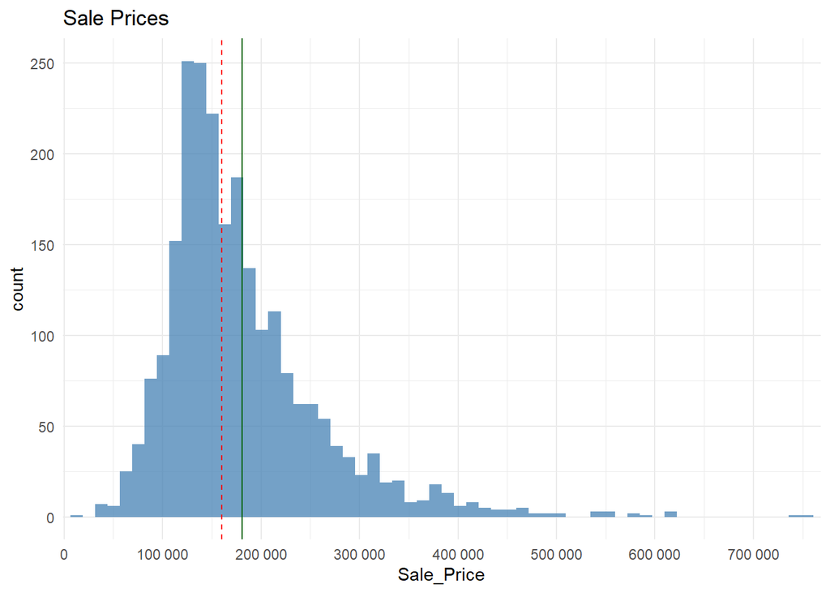

```r
px_dist <- ames_train %>%
    select(Sale_Price) %>%
    ggplot(aes(x = Sale_Price)) +
    geom_histogram(bins = 60, alpha = .75, fill = 'steelblue') +
    geom_vline(xintercept = median(ames$Sale_Price),
               color = 'red', lty = 'dashed') +
    geom_vline(xintercept = mean(ames$Sale_Price),
               color = 'darkgreen', lty = 'solid') +
    scale_x_continuous(labels = scales::label_number(),
                       breaks = scales::breaks_pretty(n = 7),
                       expand = c(0.01, 0.01)) +
    labs(title = 'Sale Prices') +
    theme_minimal()

px_dist
```

The histogram shows that the most common selling level to be around $160’000 (*median*) and the average selling price to be $180’000 (*mean*). The plot shows also a right skewed distribution which suggest there are concern with an assumption of normality. To solve this problem it could be better to log-transform the variable.

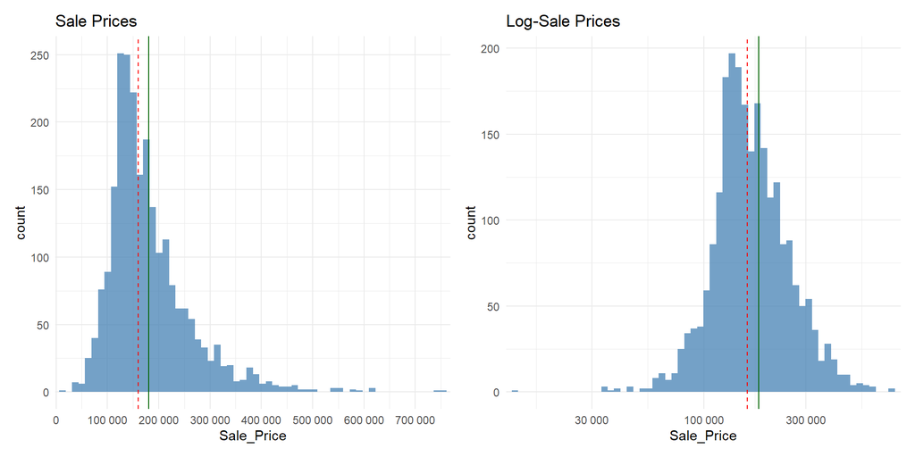

```r
px_log_dist <- px_dist +
    scale_x_log10(labels = scales::label_number(),
                  expand = c(0.01, 0.01)) +
    labs(title = 'Log-Sale Prices')

px_dist | px_log_dist
```

The log-transformation helps to meet normality assumption, highlighting a couple of interesting information. The log-transformed distribution appears to be slightly multimodal and it helps us to see a couple of outliers, with one observation where the `Sale_Price` is close to zero.

Next check the correlation between variables, to control for potential collinearity.

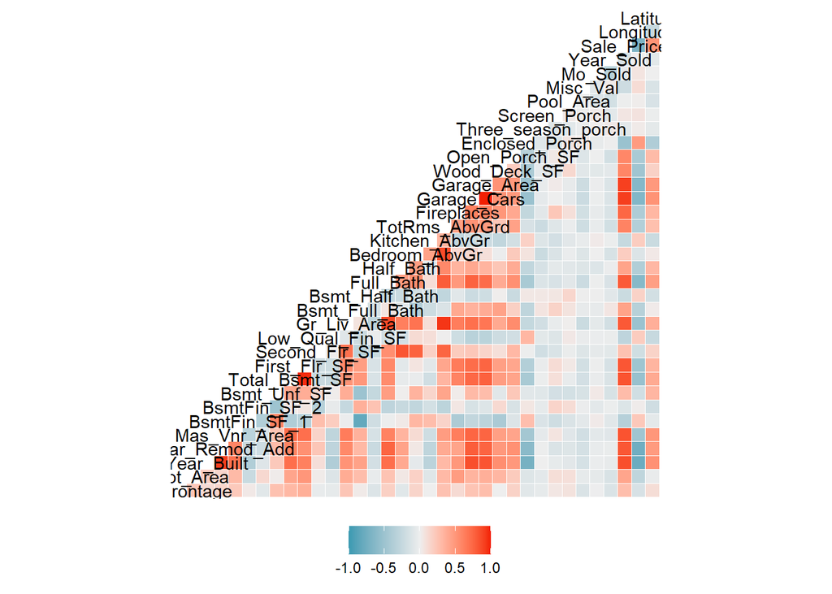

```r
ames_train %>%
    select_if(is.numeric) %>%
    cor(use = 'complete.obs') %>%
    GGally::ggcorr(label_size = 2, legend.position = 'bottom')
```

## Linear Regression

Before starting with the modelling set the metrics to use for model evaluation (RMSE).

```r
metric_set(rmse)
```

```
## # A tibble: 1 x 3
##   metric class          direction
##   <chr>  <chr>          <chr>
## 1 rmse   numeric_metric minimize
```

To get a sense of which variables are the most important I’ll start with `workflowsets::leave_var_out_formulas` which creates a list of formulas that exclude each predictor.

First declare the model specification, which will be used with all the different models.

```r
# Model Spec
lr_spec <- linear_reg() %>%
    set_mode('regression') %>%
    set_engine('lm')
```

```r
formulas <- leave_var_out_formulas(Sale_Price ~ ., data = ames)
length(formulas)
## [1] 81
```

Create the workflow set

```r
lm_wfset <- workflow_set(preproc = formulas,
                         models = list(lm = lr_spec))
```

Since we are using a linear regression, there’s nothing to tune. Thus we can use `tune::fit_resamples` passing it as a name instead of a function.

```r
# set parallel computing
doParallel::registerDoParallel()

lm_wfset <- lm_wfset %>%
    workflow_map('fit_resamples', resamples = ames_folds)
```

From the vignette of `workflowsets` I took this cool way to calculate the impact of each variable to the performance of the model. It simply calculate the difference in RMSE between the full model, the one that uses all the variables, and each model where one variable is out.

The first step is to collect the RMSE for every model and every fold (`summarize = FALSE`)

```r
# collect metrics for each model and each fold
rmse_val <- lm_wfset %>%
    # collect metrics for all models
    collect_metrics(summarize = FALSE) %>%
    # keep RMSE
    filter(.metric == 'rmse') %>%
    # remove "_lm" from the full model name
    mutate(wflow_id = gsub('_lm', '', wflow_id))
```

The second step consists in saving the full model RMSE for each fold.

```r
# extract the full model RMSE for each fold
full_model <- rmse_val %>%
    filter(wflow_id == 'everything') %>%
    select(full_model = .estimate, id)
```

The we can calculate the RMSE difference between the full model and the leave-one-out model for each fold. In order to compare the same RMSE, we merge the datasets together using the fold id.

```r
# calculate RMSE drop for each fold
differences <- rmse_val %>%
    filter(wflow_id != 'everything') %>%
    # merge models rmse with full model by fold (id)
    full_join(full_model, by = 'id') %>%
    # for each row calculate the perf increase/decrease
    mutate(perf_drop = full_model - .estimate)
```

We can then calculate for each model a summary of the RMSE (mean error, standard deviation, lower and upper limit)

```r
# calculate stats for each model
model_stats <- differences %>%
    group_by(wflow_id) %>%
    summarize(std_error = sd(perf_drop)/sum(!is.na(perf_drop)),
              perf_drop = mean(perf_drop),
              lower = perf_drop - qnorm(0.975) * std_error,
              upper = perf_drop + qnorm(0.975) * std_error,
              .groups = 'drop') %>%
    mutate(wflow_id = factor(wflow_id),
           wflow_id = forcats::fct_reorder(wflow_id, perf_drop))
```

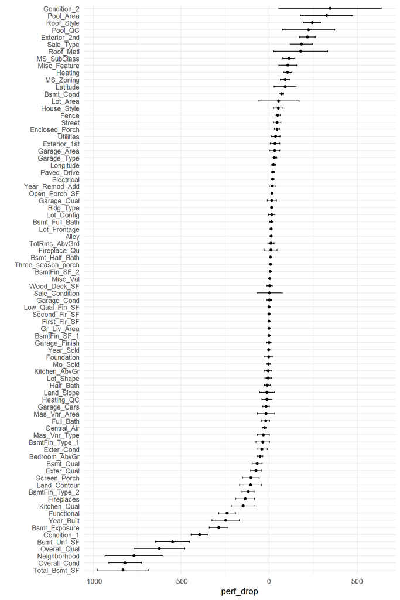

```r
ggplot(model_stats, aes(x = perf_drop, y = wflow_id)) +
  geom_point() +
  geom_errorbar(aes(xmin = lower, xmax = upper), width = .25) +
  ylab("") +
    theme_minimal()
```

Because of the high number of predictors, it makes sense to start focusing on the top 15 variables in the preprocessing.  
The baseline model vs we compare is the full model without any preprocessing except for the `recipes::step_dummy`, which will create a set of binary dummy variables. By default the excluded dummy will correspond to the first level of the unordered factor.

```r
recipe(Sale_Price ~ Garage_Type, data = ames_train[1:10, ]) %>%
    step_dummy(all_nominal_predictors()) %>%
    prep() %>%
    bake(new_data = ames_train[1:10, ])
```

```
## # A tibble: 10 x 7
##    Sale_Price Garage_Type_Basment Garage_Type_BuiltIn Garage_Type_CarPort
##         <int>               <dbl>               <dbl>               <dbl>
##  1     215000                   0                   0                   0
##  2     105000                   0                   0                   0
##  3     172000                   0                   0                   0
##  4     189900                   0                   0                   0
##  5     195500                   0                   0                   0
##  6     213500                   0                   0                   0
##  7     191500                   0                   0                   0
##  8     236500                   0                   0                   0
##  9     175900                   0                   0                   0
## 10     180400                   0                   0                   0
## # ... with 3 more variables: Garage_Type_Detchd <dbl>,
## #   Garage_Type_More_Than_Two_Types <dbl>, Garage_Type_No_Garage <dbl>
```

Next I create a basic recipe

```r
## Recipe
base_rec <-
    recipe(Sale_Price ~ ., data = ames_train) %>%
    step_dummy(all_nominal_predictors())
base_rec
## Data Recipe
##
## Inputs:
##
##       role #variables
##    outcome          1
##  predictor         80
##
## Operations:
##
## Dummy variables from all_nominal_predictors()
```

Which is added to a workflow

```r
base_wf <- workflow() %>%
    add_recipe(base_rec) %>%
    add_model(lr_spec)
base_wf
## == Workflow ====================================================================
## Preprocessor: Recipe
## Model: linear_reg()
##
## -- Preprocessor ----------------------------------------------------------------
## 1 Recipe Step
##
## * step_dummy()
##
## -- Model -----------------------------------------------------------------------
## Linear Regression Model Specification (regression)
##
## Computational engine: lm
```

And I fit and predict

```r
base_train <- fit_resamples(base_wf, ames_folds)
base_test <- last_fit(base_wf, ames_split)
```

```r
collect_metrics(base_train)
## # A tibble: 2 x 6
##   .metric .estimator      mean     n   std_err .config
##   <chr>   <chr>          <dbl> <int>     <dbl> <fct>
## 1 rmse    standard   25904.       10 1780.     Preprocessor1_Model1
## 2 rsq     standard       0.897    10    0.0159 Preprocessor1_Model1

collect_metrics(base_test)
## # A tibble: 2 x 4
##   .metric .estimator .estimate .config
##   <chr>   <chr>          <dbl> <fct>
## 1 rmse    standard   42909.    Preprocessor1_Model1
## 2 rsq     standard       0.749 Preprocessor1_Model1
```

Start by checking the 20 most important variables

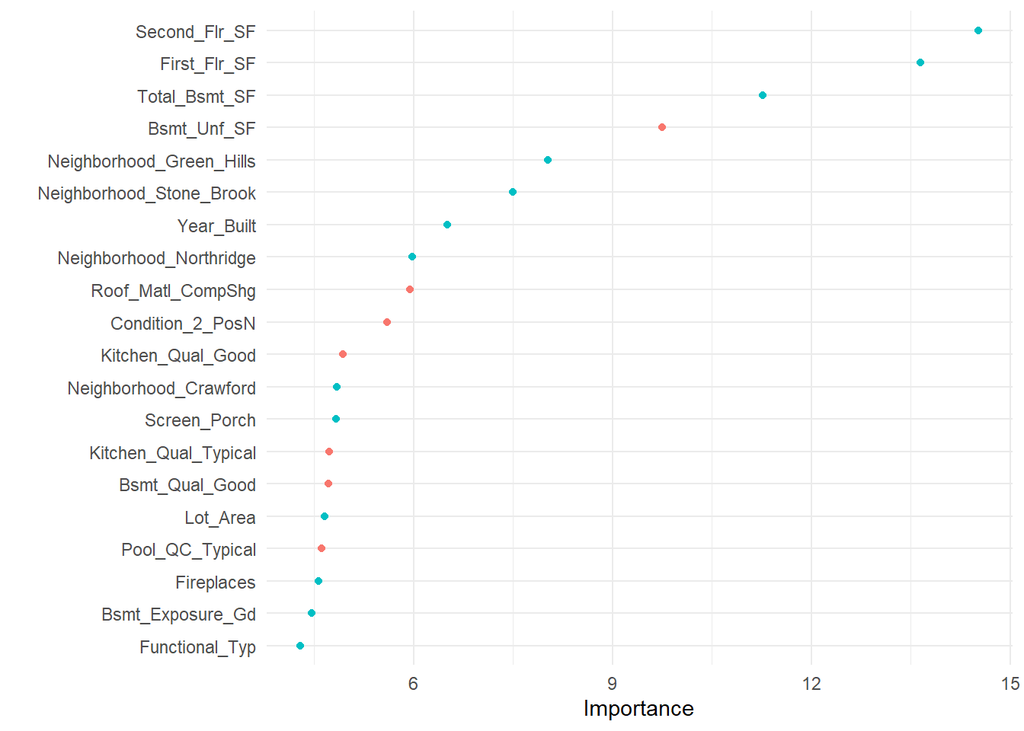

```r
base_test %>%
    extract_fit_engine() %>%
    vip::vip(n = 20L, geom = 'point', mapping = aes_string(color = 'Sign')) +
    theme_minimal() +
    theme(legend.position = 'none')
```

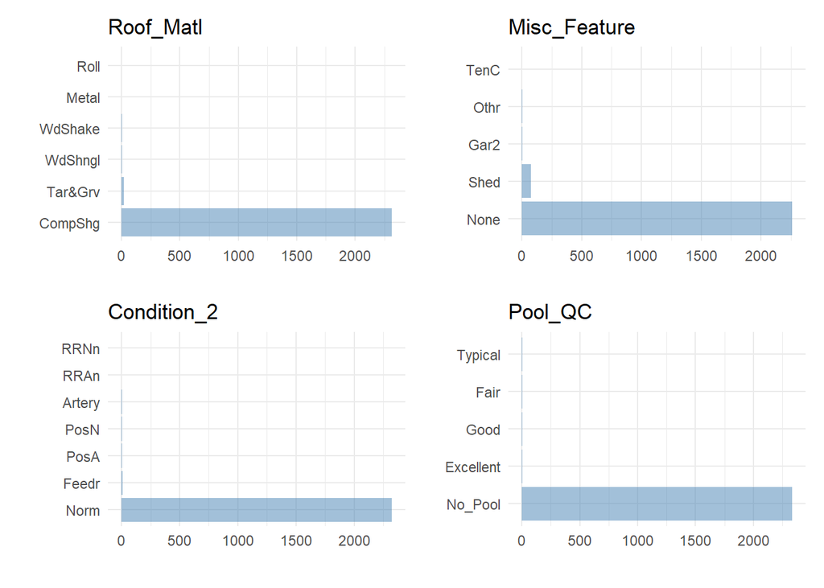

```r
c('Roof_Matl', 'Misc_Feature', 'Condition_2', 'Pool_QC') %>%
    purrr::map(nom_bar_plot, dataset = ames_train, title = .x) %>%
    wrap_plots(ncol = 2)
```

```r
# roof material
ames_train %>%
    janitor::tabyl(Roof_Matl)
##  Roof_Matl    n      percent
##    ClyTile    0 0.0000000000
##    CompShg 2317 0.9876385337
##    Membran    0 0.0000000000
##      Metal    1 0.0004262575
##       Roll    1 0.0004262575
##    Tar&Grv   20 0.0085251492
##    WdShake    3 0.0012787724
##    WdShngl    4 0.0017050298
# condition 2
ames_train %>%
    janitor::tabyl(Condition_2)
##  Condition_2    n      percent
##       Artery    2 0.0008525149
##        Feedr   10 0.0042625746
##         Norm 2326 0.9914748508
##         PosA    3 0.0012787724
##         PosN    3 0.0012787724
##         RRAe    0 0.0000000000
##         RRAn    1 0.0004262575
##         RRNn    1 0.0004262575
```

Having a column with a values equal to 99% of the observation doesn’t make a lot of sense. The next recipe will delete `Pool_QC`, `Roof_Matl` and `Condition_2` from the dataset and will collapse the factors levels of `Misc_Features` with a 3% threshold.

Let’s check `Neighborhood`

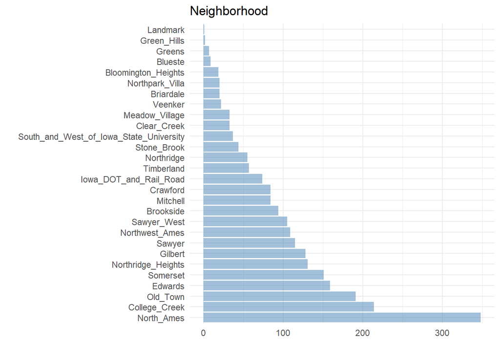

```r
nom_bar_plot(ames_train, 'Neighborhood')
```

Here there are a couple of levels which are rare. Here as well it makes sense to lump the factors with a 3% limit.

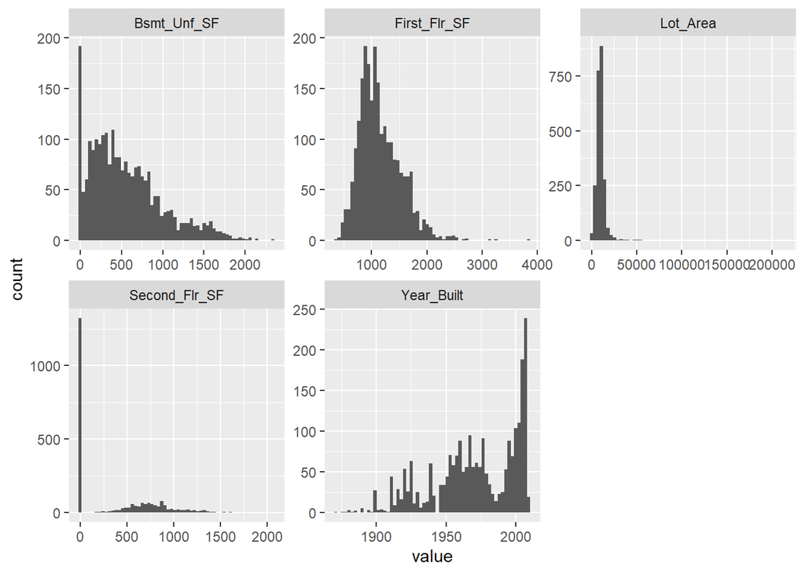

```r
ames_train %>%
    select(Sale_Price, Second_Flr_SF, First_Flr_SF,
           Bsmt_Unf_SF, Lot_Area, Year_Built) %>%
    tidyr::pivot_longer(-Sale_Price, names_to = 'var', values_to = 'value') %>%
    ggplot(aes(x = value)) +
    geom_histogram(bins = 60) +
    facet_wrap(~var, scales = 'free')
```

Let’s try to check the relationship between the variable and the target.

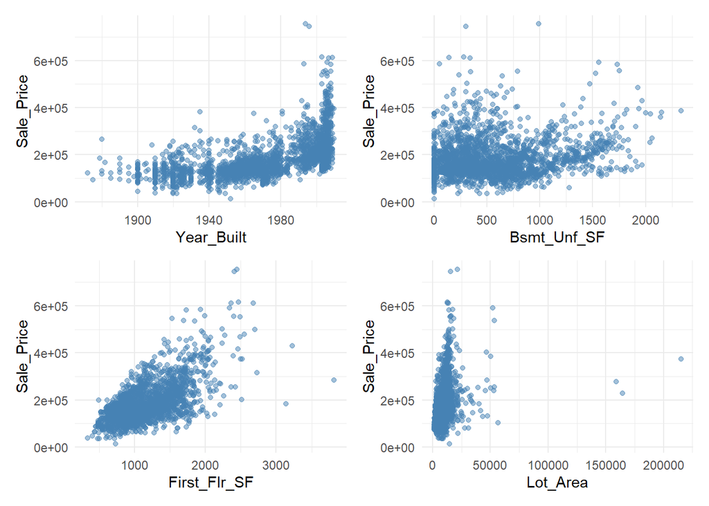

```r
p1 <- ggplot(ames_train, aes(x = Year_Built, y = Sale_Price)) +
      geom_point(color = 'steelblue', alpha = .5) +
      theme_minimal()

p2 <- ggplot(ames_train, aes(x = Bsmt_Unf_SF, y = Sale_Price)) +
      geom_point(color = 'steelblue', alpha = .5) +
      theme_minimal()

p3 <- ggplot(ames_train, aes(x = First_Flr_SF, y = Sale_Price)) +
      geom_point(color = 'steelblue', alpha = .5) +
      theme_minimal()

p4 <- ggplot(ames_train, aes(x = Lot_Area, y = Sale_Price)) +
      geom_point(color = 'steelblue', alpha = .5) +
      theme_minimal()

(p1 + p2) / (p3 + p4)
```

From the plot above the best insight is that the relationship between `Year_Built` and `Sale_Price` is not linear; it seems that a polynomial should increase the precision.

To recap, we’re going to:

- remove `Roof_Matl` and `Condition_2` with `recipes::step_rm`
- lump all factor levels below 3% in `Misc_Feature` and `Neighborhood` with `recipes::step_other`
- create a polynomial fit, degree 2, between `Sale_Price` and `Year_Built`
- remove zero-variance columns via `recipes::zv`
- create dummy vars with `recipes::dummy`

```r
## Recipe
lr_rec1 <-
    recipe(Sale_Price ~ ., data = ames_train) %>%
    # remove worthless vars
    step_rm(Roof_Matl, Condition_2, Pool_QC) %>%
    step_other(Misc_Feature, Neighborhood, threshold = 0.03) %>%
    step_poly(Year_Built, degree = 2) %>%
    step_zv(all_predictors()) %>%
    step_dummy(all_nominal_predictors())

#W update workflow
rec1_wf <- base_wf %>%
    update_recipe(lr_rec1)


rec1_train <- fit_resamples(rec1_wf, ames_folds)

rec1_test <- last_fit(rec1_wf, ames_split)
```

```r
collect_metrics(rec1_train)
## # A tibble: 2 x 6
##   .metric .estimator      mean     n   std_err .config
##   <chr>   <chr>          <dbl> <int>     <dbl> <fct>
## 1 rmse    standard   25077.       10 1712.     Preprocessor1_Model1
## 2 rsq     standard       0.903    10    0.0155 Preprocessor1_Model1
collect_metrics(rec1_test)
## # A tibble: 2 x 4
##   .metric .estimator .estimate .config
##   <chr>   <chr>          <dbl> <fct>
## 1 rmse    standard   41780.    Preprocessor1_Model1
## 2 rsq     standard       0.761 Preprocessor1_Model1
```

Let’s check again the variables importance

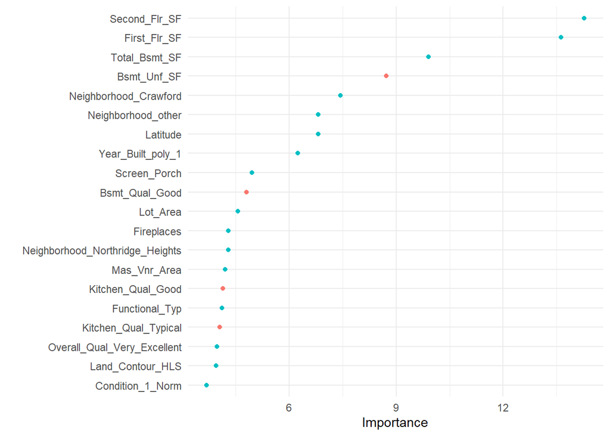

```r
rec1_test %>%
    extract_fit_engine() %>%
    vip::vip(n = 20L, geom = 'point', mapping = aes_string(color = 'Sign')) +
    theme_minimal() +
    theme(legend.position = 'none')
```

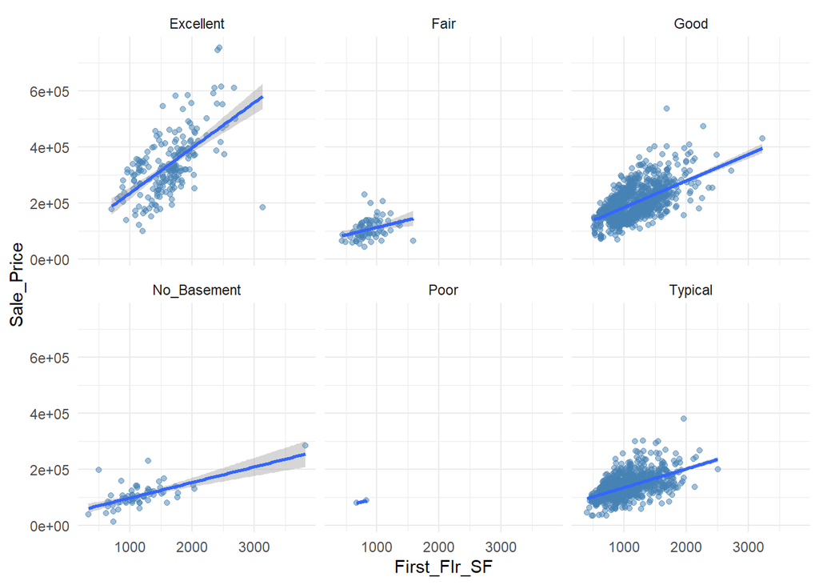

```r
ggplot(ames_train, aes(x = First_Flr_SF, y = Sale_Price)) +
      geom_point(color = 'steelblue', alpha = .5) +
      facet_wrap(~Bsmt_Qual) +
      geom_smooth(method = 'lm') +
      theme_minimal()
```

```r
## Recipe
lr_rec2 <-
    recipe(Sale_Price ~ ., data = ames_train) %>%
    # remove worthless vars
    step_rm(Roof_Matl, Condition_2, Pool_QC) %>%
    step_other(Misc_Feature, Neighborhood, threshold = 0.03) %>%
    step_poly(Year_Built, degree = 2) %>%
    step_interact(First_Flr_SF ~ Bsmt_Qual) %>%
    step_dummy(all_nominal_predictors()) %>%
    step_zv(all_predictors())


# update workflow
rec2_wf <- rec1_wf %>%
    update_recipe(lr_rec2)

rec2_train <- fit_resamples(rec2_wf, ames_folds)

rec2_test <- last_fit(rec2_wf, ames_split)
```

```r
collect_metrics(rec2_train)
```

[output not shown]

```r
collect_metrics(rec2_test)
```

[output not shown]

## Penalized Regression

In general the *penalized regressions*, Ridge, Lasso and ElasticNet, are a way to augment the reduce bias in order to reduce the variance. They do this by adding a penalty to the OLS, this penalty basically reduce the variables’ $\beta$.

### Ridge Regression

*Ridge regression* is very similar to OLS, except that the coefficients are estimated by minimizing a different quantity. The *ridge regression* coefficients are the values that minimize

$$\sum^n_{i=1}\bigg(y_i - \beta_0 - \sum^p_{j=1} \beta_j x_{ij} \bigg) + \lambda \sum^p_{j=1} \beta^2_j = RSS + \lambda \sum^p_{j=1} \beta^2_j$$

where $\lambda$ is a tuning parameter. Like OLS, ridge regression seeks coefficients estimates that minimize the RSS, however the *shrinkage penalty*, also called $L_2$, $\lambda \sum^p_{j=1} \beta^2_j$ is small when $\beta_1,...,\beta_p$ are close to zero, effectively shrinking the estimates of $\beta_j$ towards zero. The tuning parameter $\lambda$ serves to control the relative impact of these two terms; when $\lambda = 0$ the penalty term has no effect and the ridge regression will produce the least squared estimates. As $\lambda \rightarrow \infty$ the impact of the penalty term grows and the coefficients are reduced to a point where they will approach zero.

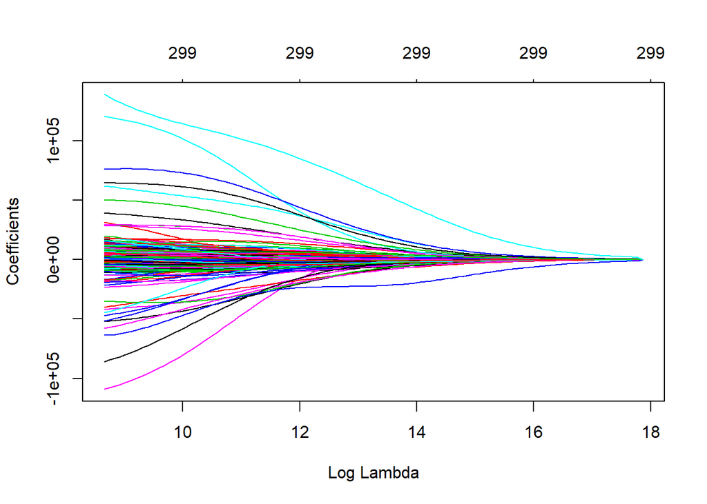

```r
# set test model spec (penalty not-tuned)
linear_reg(mixture = 0, penalty = 0) %>%
    set_mode('regression') %>%
    set_engine('glmnet') %>%
    # fit on train data
    fit(Sale_Price ~ ., ames_train) %>%
    # plot coefficients regularization
    .$fit %>%
    plot(xvar = 'lambda')
```

The engine to use for *ridge regression* is `glmnet`. In the model specification we need to select `linear_reg` with `mixture = 0`; the *mixture* parameter specifies if we want to use a ridge regularization (value 0), a lasso regularization (value 1) or an elastic net regularization (between 0 and 1).  
The `penalty` value is the equivalent of $\lambda$ and it is a tunable parameter; to tune the model we need a `workflow` object containing:

- a `parsnip` model specification
- a `recipe` preprocessor
- an `rset` object containing the resamples to be fitted
- a `tibble` with the parameter values to be evaluated.

```r
# set model spec
ridge_spec <- linear_reg(mixture = 0, penalty = tune()) %>%
    set_mode('regression') %>%
    set_engine('glmnet')

# set recipe
ridge_rec <-
    base_rec %>%
    step_zv(all_predictors()) %>%
    # ridge needs normalized variables
    step_normalize(all_predictors())

# set workflow
ridge_wf <- workflow() %>%
    add_recipe(ridge_rec) %>%
    add_model(ridge_spec)

# create the 'penalty' grid search for tuning
penalty_grid <- grid_regular(penalty(range = c(-10, 10)), levels = 50)

# tune ridge penalty hyperparameter
n_core <- parallel::detectCores() -1
cluster <- parallel::makeCluster(n_core)

doParallel::registerDoParallel(cl = cluster)
set.seed(111)

ridge_tune <- tune_grid(ridge_wf,
                        resamples = ames_folds,
                        grid      = penalty_grid)
```

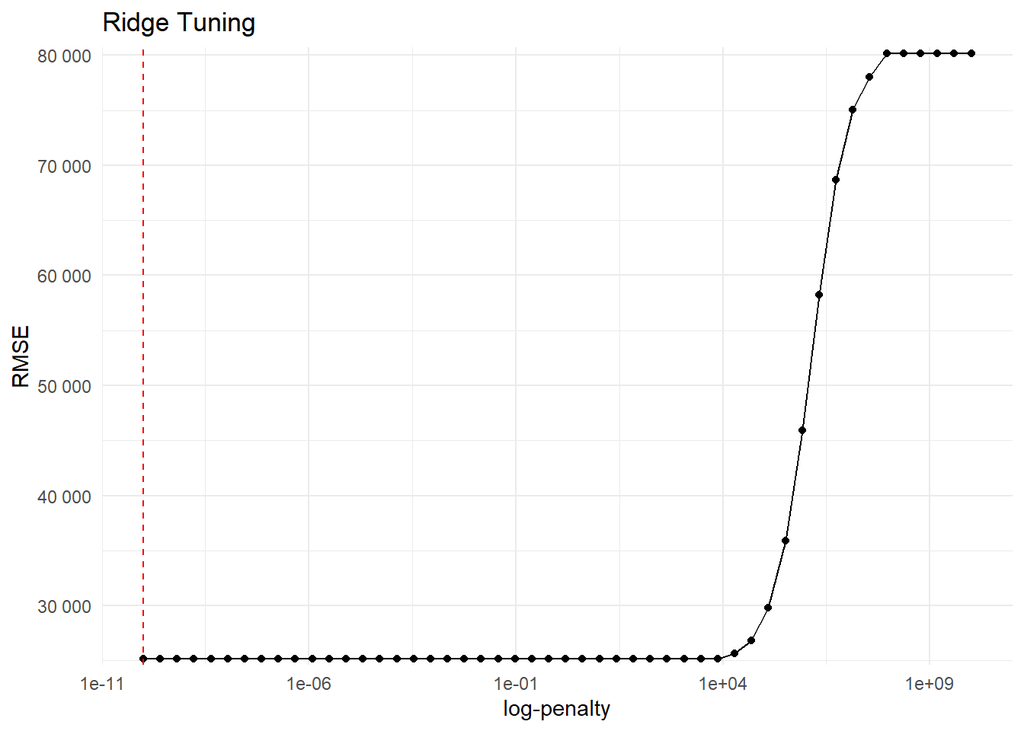

```r
ridge_best <- select_best(ridge_tune, metric = 'rmse')
ridge_1sd <- select_by_one_std_err(ridge_tune, metric = 'rmse', penalty)

ridge_tune %>%
    collect_metrics() %>%
    filter(.metric == 'rmse') %>%
    ggplot(aes(x = penalty, y = mean)) +
    geom_point() +
    geom_line() +
    geom_vline(xintercept = ridge_best$penalty, lty = 2, color = 'darkgray') +
    geom_vline(xintercept = ridge_1sd$penalty, lty = 2, color = 'red') +
    scale_x_log10() +
    scale_y_continuous(labels = scales::number_format(), expand = c(0.01, 0.01)) +
    labs(title = 'Ridge Tuning', x = 'log-penalty', y = 'RMSE') +
    theme_minimal()
```

```r
ridge_tune %>%
    show_best(metric = 'rsq')
## # A tibble: 5 x 7
##    penalty .metric .estimator  mean     n std_err .config
##      <dbl> <chr>   <chr>      <dbl> <int>   <dbl> <fct>
## 1 1   e-10 rsq     standard   0.902    10  0.0159 Preprocessor1_Model01
## 2 2.56e-10 rsq     standard   0.902    10  0.0159 Preprocessor1_Model02
## 3 6.55e-10 rsq     standard   0.902    10  0.0159 Preprocessor1_Model03
## 4 1.68e- 9 rsq     standard   0.902    10  0.0159 Preprocessor1_Model04
## 5 4.29e- 9 rsq     standard   0.902    10  0.0159 Preprocessor1_Model05

ridge_tune %>%
    show_best(metric = 'rmse')
## # A tibble: 5 x 7
##    penalty .metric .estimator   mean     n std_err .config
##      <dbl> <chr>   <chr>       <dbl> <int>   <dbl> <fct>
## 1 1   e-10 rmse    standard   25140.    10   1736. Preprocessor1_Model01
## 2 2.56e-10 rmse    standard   25140.    10   1736. Preprocessor1_Model02
## 3 6.55e-10 rmse    standard   25140.    10   1736. Preprocessor1_Model03
## 4 1.68e- 9 rmse    standard   25140.    10   1736. Preprocessor1_Model04
## 5 4.29e- 9 rmse    standard   25140.    10   1736. Preprocessor1_Model05
```

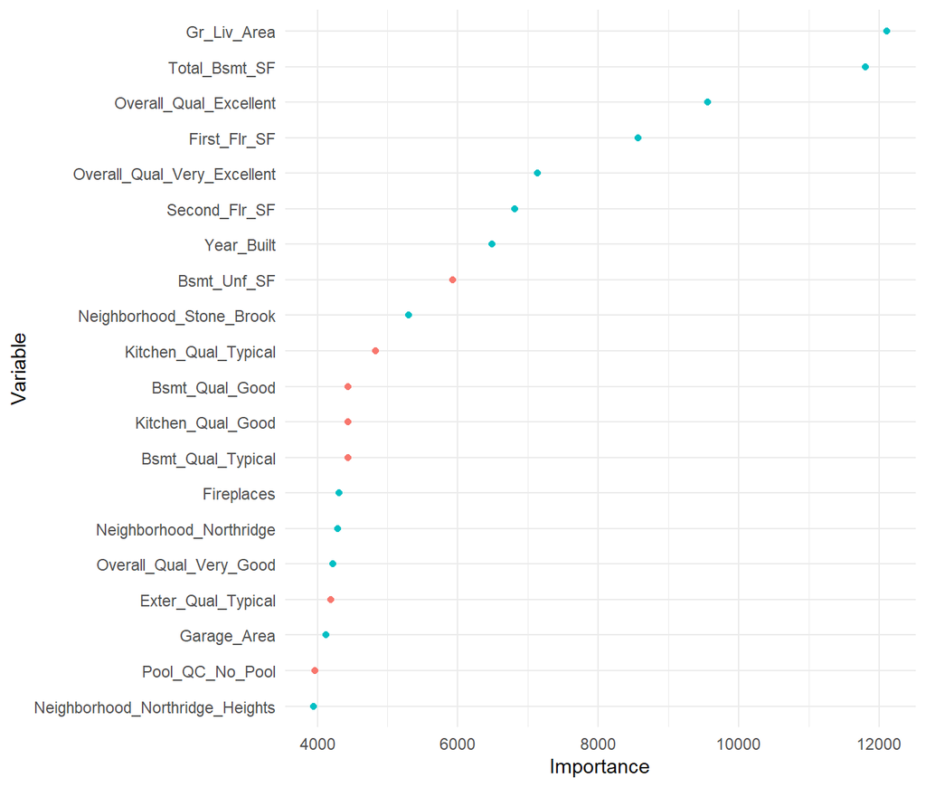

```r
ridge_rmse <- ridge_tune %>% select_best('rmse')

final_ridge <- finalize_workflow(ridge_wf, ridge_rmse)

final_ridge %>%
    fit(ames_train) %>%
    extract_fit_engine() %>%
    vip::vi(lambda = ridge_rmse$penalty) %>%
    mutate(Importance = abs(Importance),
           Variable = forcats::fct_reorder(Variable, Importance)) %>%
    slice_max(Importance, n = 20) %>%
    ggplot(aes(x = Importance, y = Variable, color = Sign)) +
    geom_point() +
    theme_minimal() +
    theme(legend.position = 'none')
```

```r
last_fit(final_ridge, ames_split) %>% collect_metrics()
```

```
## # A tibble: 2 x 4
##   .metric .estimator .estimate .config
##   <chr>   <chr>          <dbl> <fct>
## 1 rmse    standard   39940.    Preprocessor1_Model1
## 2 rsq     standard       0.772 Preprocessor1_Model1
```

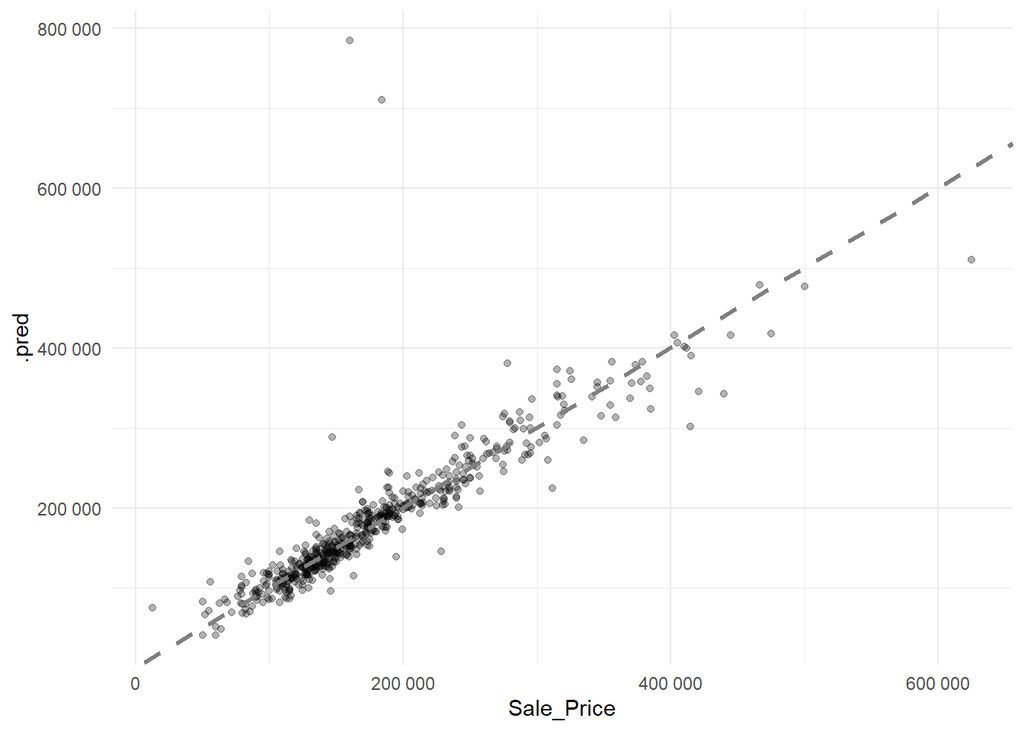

```r
final_ridge %>%
    last_fit(ames_split) %>%
    collect_predictions() %>%
    ggplot(aes(x = Sale_Price, y = .pred)) +
    geom_point(alpha = .3) +
    geom_abline(lty = 2, color = 'gray50', size = 1.2) +
    theme_minimal() +
    scale_x_continuous(labels = scales::number_format()) +
    scale_y_continuous(labels = scales::number_format())
```

### Lasso Regression

The *least absolute shrinkage and selection operator* (lasso) model is an alternative to ridge regression that has a small modification to the penalty in the objective function. Rather than the $L_2$ penalty it uses the $L_1$ penalty $\lambda\sum^p_{j=1}|\beta_j|$ in the objective function.

The lasso coefficients are the ones that minimize the function:

$$\sum^n_{i=1}\bigg(y_i - \beta_0 - \sum^p_{j=1} \beta_j x_{ij} \bigg) + \lambda \sum^p_{j=1} |\beta_j| = RSS + \lambda \sum^p_{j=1} |\beta_j|$$

Whereas the ridge regression approach pushes variables to approximately but not equal to zero, the lasso penalty will actually push coefficients to zero. Thus the lasso model not only improves the model with regularization but it also conducts automated feature selection.

Use mixture = 1 in glmnet.

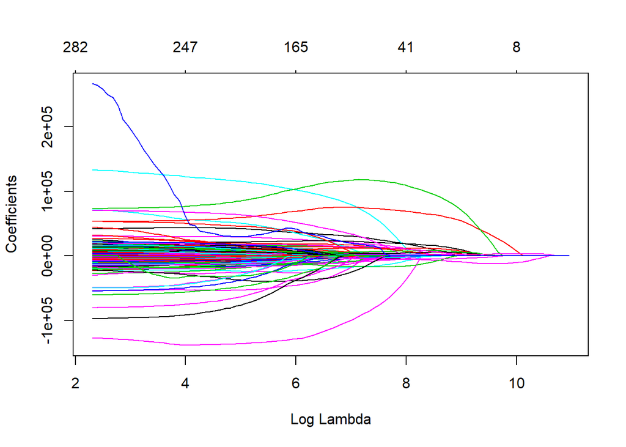

```r
# set test model spec (penalty not-tuned)
linear_reg(mixture = 1, penalty = 0) %>%
    set_mode('regression') %>%
    set_engine('glmnet') %>%
    # fit on train data
    fit(Sale_Price ~ ., ames_train) %>%
    # plot coefficients regularization
    .$fit %>%
    plot(xvar = 'lambda')
```

We can re-use the ridge recipe in the lasso workflow

```r
lasso_spec <- linear_reg(mixture = 1, penalty = tune()) %>%
    set_mode('regression') %>%
    set_engine('glmnet')

lasso_wf <- workflow() %>%
    add_recipe(ridge_rec) %>%
    add_model(lasso_spec)

penalty_grid <- grid_regular(penalty(range = c(-10, 10)),
                             levels = 50)

lasso_tune <- tune_grid(lasso_wf,
                        resamples = ames_folds,
                        grid      = penalty_grid)
```

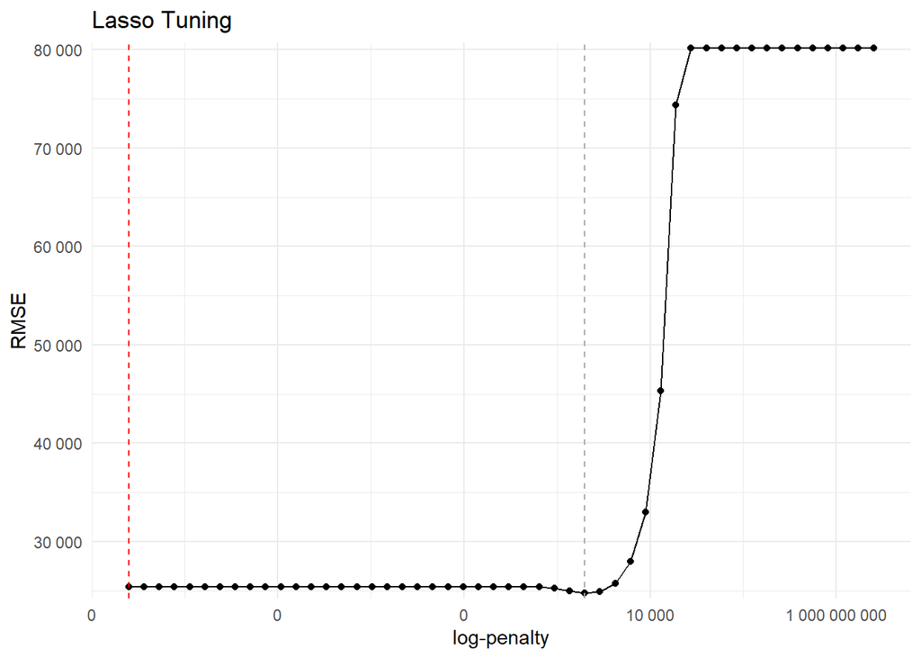

```r
lasso_best <- select_best(lasso_tune, metric = 'rmse')
lasso_1sd <- select_by_one_std_err(lasso_tune, metric = 'rmse', penalty)

lasso_tune %>%
    collect_metrics() %>%
    filter(.metric == 'rmse') %>%
    ggplot(aes(x = penalty, y = mean)) +
    geom_point() +
    geom_line() +
    geom_vline(xintercept = lasso_best$penalty, lty = 2, color = 'darkgray') +
    geom_vline(xintercept = lasso_1sd$penalty, lty = 2, color = 'red') +
    scale_x_log10(labels = scales::number_format(accuracy = 1)) +
    scale_y_continuous(labels = scales::number_format(), expand = c(0.01, 0.01)) +
    labs(title = 'Lasso Tuning', x = 'log-penalty', y = 'RMSE') +
    theme_minimal()
```

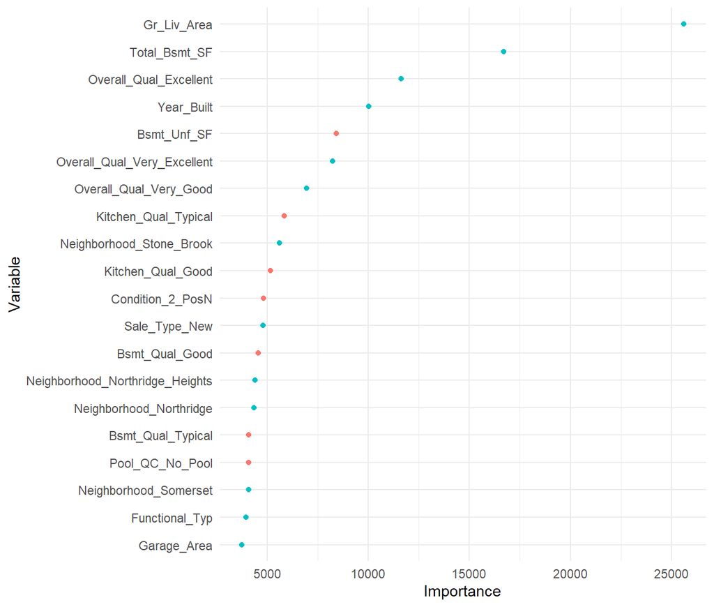

```r
lasso_penalty <- lasso_tune %>% select_best(metric = 'rmse')

final_lasso <- finalize_workflow(lasso_wf, lasso_penalty)

final_lasso %>%
    fit(ames_train) %>%
    extract_fit_engine() %>%
    vip::vi(lambda = lasso_penalty$penalty) %>%
    mutate(Importance = abs(Importance),
           Variable   = forcats::fct_reorder(Variable, Importance)) %>%
    slice_max(Importance, n = 20) %>%
    ggplot(aes(x = Importance, y = Variable, color = Sign)) +
    geom_point() +
    theme_minimal() +
    theme(legend.position = 'none')
```

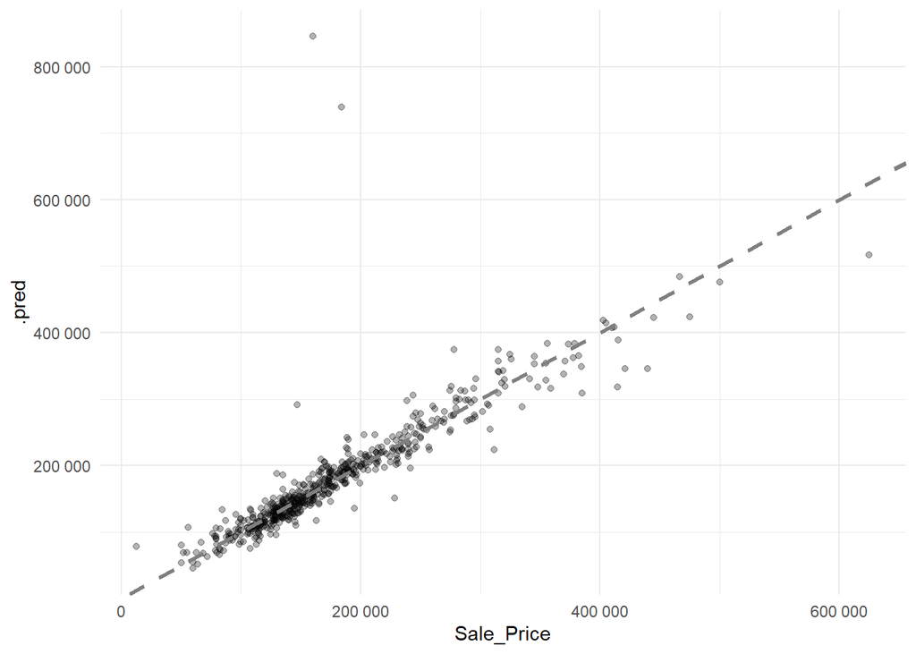

```r
final_lasso %>%
    last_fit(ames_split) %>%
    collect_predictions() %>%
    ggplot(aes(x = Sale_Price, y = .pred)) +
    geom_point(alpha = .3) +
    geom_abline(lty = 2, color = 'gray50', size = 1.2) +
    theme_minimal() +
    scale_x_continuous(labels = scales::number_format()) +
    scale_y_continuous(labels = scales::number_format())
```

### Elastic Net

The advantage of *elastic net* model is that it enables effective regularization via the ridge penalty with the feature selection characteristic of the lasso penalty.

In risge and lasso models $\lambda$ is the primary tuning parameter, but with elastic nets, we want to tune the $\lambda$ and the `mixture` parameters.

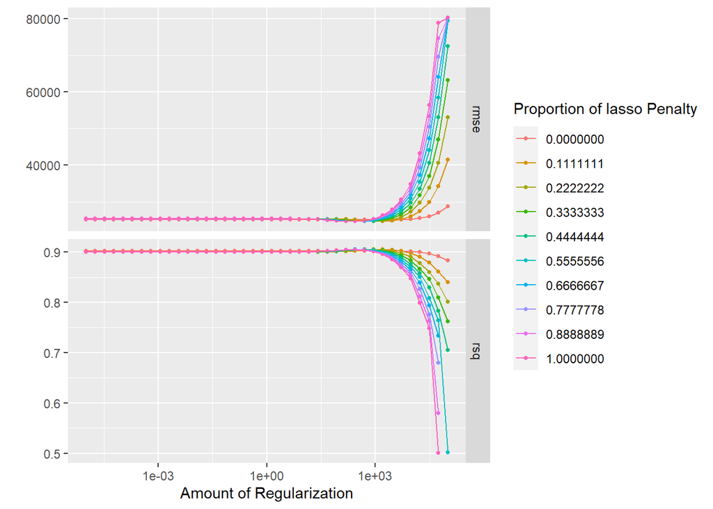

```r
# set elatic net model
elnet_spec <- linear_reg(mixture = tune(), penalty = tune()) %>%
    set_mode('regression') %>%
    set_engine('glmnet')

# workflow (use ridge recipe)
elnet_wf <- workflow() %>%
    add_recipe(ridge_rec) %>%
    add_model(elnet_spec)

# hyper-parameters grid
elnet_grid <- grid_regular(mixture(range = c(0, 1)),
                           penalty(range = c(-5, 5)),
                           levels = c(10, 40))
# activate parallel computing
#doParallel::registerDoParallel()

# set seed for reproducibility
set.seed(2020)

# tune elastic net model
elnet_tune <- tune_grid(elnet_wf,
                        resamples = ames_folds,
                        grid      = elnet_grid)

# plot RMSE / R-squared
autoplot(elnet_tune)
```

```r
# best 5 models by R-sq
elnet_tune %>% show_best('rsq')
## # A tibble: 5 x 8
##   penalty mixture .metric .estimator  mean     n std_err .config
##     <dbl>   <dbl> <chr>   <chr>      <dbl> <int>   <dbl> <fct>
## 1   1604.   0.111 rsq     standard   0.905    10  0.0163 Preprocessor1_Model073
## 2    889.   0.222 rsq     standard   0.905    10  0.0164 Preprocessor1_Model112
## 3    273.   0.667 rsq     standard   0.905    10  0.0165 Preprocessor1_Model270
## 4    492.   0.444 rsq     standard   0.905    10  0.0165 Preprocessor1_Model191
## 5    492.   0.333 rsq     standard   0.905    10  0.0165 Preprocessor1_Model151

# best 5 models by RMSE
elnet_tune %>% show_best('rmse')
## # A tibble: 5 x 8
##   penalty mixture .metric .estimator   mean     n std_err .config
##     <dbl>   <dbl> <chr>   <chr>       <dbl> <int>   <dbl> <fct>
## 1   1604.   0.111 rmse    standard   24711.    10   1773. Preprocessor1_Model073
## 2    889.   0.222 rmse    standard   24713.    10   1782. Preprocessor1_Model112
## 3    273.   0.667 rmse    standard   24724.    10   1790. Preprocessor1_Model270
## 4    492.   0.333 rmse    standard   24727.    10   1792. Preprocessor1_Model151
## 5    273.   0.778 rmse    standard   24731.    10   1787. Preprocessor1_Model310
```

## Tree-based methods

Fit regression tree

```r
tree_spec <- decision_tree(cost_complexity = tune()) %>%
    set_engine('rpart') %>%
    set_mode('regression')

tree_wf <- workflow() %>%
    add_model(tree_spec) %>%
    add_formula(Sale_Price ~ .)

tree_grid <- grid_regular(cost_complexity(range = c(-4, -1)), levels = 10)

tree_tune <- tune_grid(tree_wf,
                       resamples = ames_folds,
                       grid      = tree_grid)
```

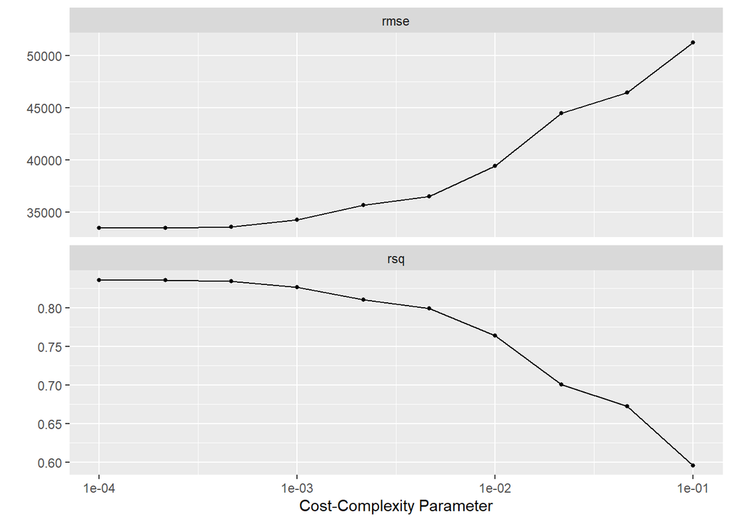

```r
autoplot(tree_tune)
```

```r
best_complexity <- select_best(tree_tune, metric = "rmse")

tree_final <- finalize_workflow(tree_wf, best_complexity)

tree_final_fit <- fit(tree_final, data = ames_train)
tree_final_fit
```

```
## == Workflow [trained] ==========================================================
## Preprocessor: Formula
## Model: decision_tree()
##
## -- Preprocessor ----------------------------------------------------------------
## Sale_Price ~ .
##
## -- Model -----------------------------------------------------------------------
## n= 2346
##
## node), split, n, deviance, yval
##       * denotes terminal node
##
##    1) root 2346 1.515597e+13 181002.30
##      2) Overall_Qual=Very_Poor,Poor,Fair,Below_Average,Average,Above_Average,Good 1959 4.526471e+12 156265.50
##        4) Neighborhood=North_Ames,Old_Town,Edwards,Sawyer,Mitchell,Brookside,Iowa_DOT_and_Rail_Road,South_and_West_of_Iowa_State_University,Meadow_Village,Briardale,Northpark_Villa,Blueste,Landmark 1170 1.447883e+12 132106.50
##          8) Overall_Qual=Very_Poor,Poor,Fair,Below_Average 222 1.795790e+11  97892.54
##           16) First_Flr_SF< 826.5 92 5.091242e+10  81108.90
##             32) Overall_Qual=Very_Poor,Poor 11 3.452041e+09  48721.82 *
##             33) Overall_Qual=Fair,Below_Average 81 3.435532e+10  85507.15
##               66) Gr_Liv_Area< 1132 62 1.748009e+10  79956.92
##                132) Central_Air=N 21 5.455207e+09  67818.52 *
##                133) Central_Air=Y 41 7.345920e+09  86174.15 *
##               67) Gr_Liv_Area>=1132 19 8.732966e+09 103618.40 *
##           17) First_Flr_SF>=826.5 130 8.441088e+10 109770.20
##             34) Exterior_1st=AsbShng,BrkComm,CBlock,Stucco,Wd Sdng,WdShing 43 1.736674e+10  93830.00
##               68) Garage_Cond=Fair,No_Garage 19 5.108014e+09  80337.84 *
##               69) Garage_Cond=Good,Typical 24 6.061838e+09 104511.30 *
##             35) Exterior_1st=BrkFace,HdBoard,MetalSd,Plywood,VinylSd 87 5.071816e+10 117648.70
##               70) Open_Porch_SF< 52.5 74 2.998023e+10 113111.60
##                140) Sale_Condition=Abnorml 13 4.380647e+09  92265.38 *
##                141) Sale_Condition=Alloca,Normal 61 1.874628e+10 117554.20
##                  282) Bedroom_AbvGr< 2.5 30 7.790303e+09 109243.60 *
##                  283) Bedroom_AbvGr>=2.5 31 6.878840e+09 125596.80 *
##               71) Open_Porch_SF>=52.5 13 1.054365e+10 143475.00 *
##          9) Overall_Qual=Average,Above_Average,Good 948 9.475752e+11 140118.70
##           18) First_Flr_SF< 1150.5 664 3.681771e+11 130443.80
##             36) Gr_Liv_Area< 1488 537 2.154085e+11 125772.70
##               72) MS_SubClass=One_Story_1945_and_Older,One_and_Half_Story_Unfinished_All_Ages,One_and_Half_Story_Finished_All_Ages,Two_Story_1945_and_Older,Two_and_Half_Story_All_Ages,Duplex_All_Styles_and_Ages,Two_Story_PUD_1946_and_Newer,Two_Family_conversion_All_Styles_and_Ages 252 9.245229e+1…
##                144) Gr_Liv_Area< 1263 153 4.502954e+10 109733.30
##                  288) Neighborhood=Old_Town,Edwards,Iowa_DOT_and_Rail_Road,South_and_West_of_Iowa_State_University,Meadow_Village,Briardale 102 3.040083e+10 105388.50
##                    576) Gr_Liv_Area< 915.5 23 5.268158e+09  92932.61 *
##                    577) Gr_Liv_Area>=915.5 79 2.052530e+10 109014.90
##                     1154) First_Flr_SF< 665 25 3.728878e+09  98592.00 *
##                     1155) First_Flr_SF>=665 54 1.282310e+10 113840.40 *
##                  289) Neighborhood=North_Ames,Sawyer,Brookside,Blueste 51 8.852427e+09 118422.70 *
##                145) Gr_Liv_Area>=1263 99 3.119284e+10 126165.40
##                  290) Garage_Area< 399 62 1.499345e+10 120365.00 *
##                  291) Garage_Area>=399 37 1.061789e+10 135885.10
##                    582) Exterior_1st=AsbShng,HdBoard,WdShing 7 2.310449e+09 113285.70 *
##                    583) Exterior_1st=BrkFace,MetalSd,Plywood,VinylSd,Wd Sdng 30 3.898110e+09 141158.30 *
##               73) MS_SubClass=One_Story_1946_and_Newer_All_Styles,One_Story_with_Finished_Attic_All_Ages,Two_Story_1946_and_Newer,Split_or_Multilevel,Split_Foyer,One_Story_PUD_1946_and_Newer,PUD_Multilevel_Split_Level_Foyer 285 7.934285e+10 134247.00
##                146) MS_SubClass=One_Story_1946_and_Newer_All_Styles,One_Story_with_Finished_Attic_All_Ages,One_Story_PUD_1946_and_Newer 225 4.995463e+10 130498.60
##                  292) Total_Bsmt_SF< 950.5 100 1.987580e+10 123555.40
##                    584) Bsmt_Full_Bath< 0.5 60 1.191110e+10 118599.80
##                     1168) Bsmt_Unf_SF< 35 9 2.317629e+09 100298.10 *
##                     1169) Bsmt_Unf_SF>=35 51 6.046911e+09 121829.50 *
##                    585) Bsmt_Full_Bath>=0.5 40 4.281052e+09 130988.80 *
##
## ...
## and 170 more lines.
```

[figure not shown]

```r
tree_final_fit %>%
  extract_fit_engine() %>%
  rpart.plot::rpart.plot(roundint = FALSE)
```

## Bagging

A bagging model is the same as a random forest where mtry is equal to the number of predictors. We can specify the mtry to be .cols() which means that the number of columns in the predictor matrix is used. This is useful if you want to make the specification more general and usable to many different data sets. .cols() is one of many descriptors in the parsnip package. We also set importance = TRUE in set_engine() to tell the engine to save the information regarding variable importance. This is needed for this engine if we want to use the vip package later.

```r
bagging_spec <- rand_forest(mtry = .cols()) %>%
    set_engine('randomForest', importance = TRUE) %>%
    set_mode('regression')

bagging_fit <- fit(bagging_spec, Sale_Price ~ ., data = ames_train)
```

```r
bagging_fit %>%
    augment(new_data = ames_train) %>%
    rmse(truth = Sale_Price, estimate = .pred)
```

```
## # A tibble: 1 x 3
##   .metric .estimator .estimate
##   <chr>   <chr>          <dbl>
## 1 rmse    standard      10632.
```

Next, let us take a look at the variable importance

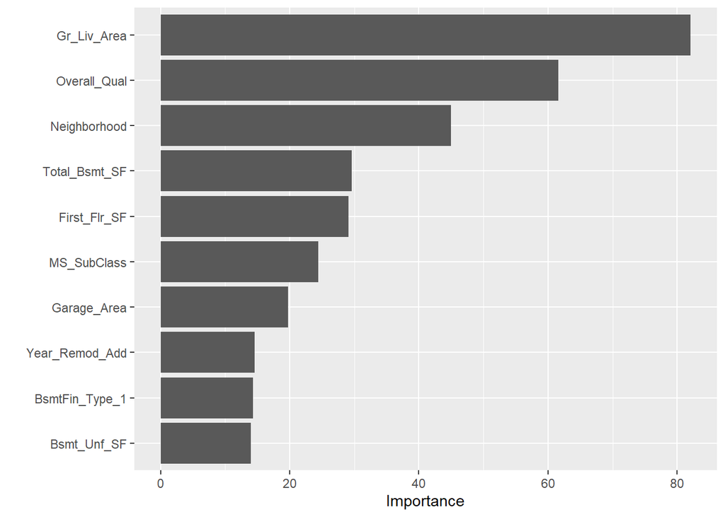

```r
vip::vip(bagging_fit)
```

[^1]: De Cock D. 2011. Ames, Iowa: Alternative to the Boston Housing Data as an End of Semester Regression Project. Journal of Statistics Education; 19(3)